# Study of COVID-19 Vaccine Hesitancy

Weiquan Luo

2022-07-27

# Introduction

This study focus on discovering the signs of vaccine hesitancy based upon the overall population. The area of intereste are the states of Connecticut (CT) and South Dakota (SD). Note that CT has approximately four times in populaton compare to SD.

With the given data, the time series and the daily change distribution of the following aspects were investigated:

- Comparison between the number of Distributed vs Administered vaccine: Do the supply and consumption of the vaccine equal?
  - by Location, measured in Number of vaccine
  - by Vaccines type and Locations, measured in Number of vaccine
  - by Age range and Locations, measured in Number of vaccine
- Comparison between Series_complete vs Administered_Dose1_Receipt: Is vaccine hesitancy of completion of series?
  - by Age range and Locations, measured in Population
  - by Age range and Locations, measured in Population proportion
- Comparison between Vaccine: Is vaccine preferences exist?
  - by Age range and Locations, measured in Population

# Data and Interpretation

[output not shown]

# Finding

# Future work

- Perform two-sample Kolmogorov-Smirnov test for goodness of fit to make comparison
- Calculate the ratio between daily rate of distributed and Administered: $\frac{\delta \text{distributed dose}}{\delta \text{Administered dose}}$ to quantify the spontaneous demand/supply and assess the distributing efficiency.

# Appendix

## Load data

```python
import copy
import pandas as pd
import numpy as np
import seaborn as sns
import matplotlib.pyplot as plt
from scipy import stats

%matplotlib notebook
%matplotlib inline
```

```python
vacc = pd.read_excel('raw data.xlsx', sheet_name='COVID-19_Vaccinations_in_the_Un')
case = pd.read_excel('raw data.xlsx', sheet_name='United_States_COVID-19_Cases_an')
```

```python
vacc = vacc[(vacc["Location"] == 'CT') | (vacc["Location"] == 'SD')]
vacc=vacc.rename({'Dist_Per_100K': 'Distributed_Per_100K'}, axis=1)
vacc = vacc.rename({'Administered_Dose1_Recip': 'Administered_Dose1_Recip_Yes'}, axis=1)
vacc = vacc.rename({'Administered_Dose1_Pop_Pct': 'Administered_Dose1_Recip_Pop_Pct'}, axis = 1)
```

```python
print(f'COVID-19_Vaccinations_in_the_Un: \n {vacc.columns}')
print(f'United_States_COVID-19_Cases_an: \n {case.columns}')
```

```
COVID-19_Vaccinations_in_the_Un:
 Index(['Date', 'MMWR_week', 'Location', 'Distributed', 'Distributed_Janssen',
       'Distributed_Moderna', 'Distributed_Pfizer', 'Distributed_Unk_Manuf',
       'Distributed_Per_100K', 'Distributed_Per_100k_12Plus',
       'Distributed_Per_100k_18Plus', 'Distributed_Per_100k_65Plus',
       'Administered', 'Administered_12Plus', 'Administered_18Plus',
       'Administered_65Plus', 'Administered_Janssen', 'Administered_Moderna',
       'Administered_Pfizer', 'Administered_Unk_Manuf', 'Admin_Per_100K',
       'Admin_Per_100k_12Plus', 'Admin_Per_100k_18Plus',
       'Admin_Per_100k_65Plus', 'Recip_Administered',
       'Administered_Dose1_Recip_Yes', 'Administered_Dose1_Recip_Pop_Pct',
       'Administered_Dose1_Recip_12Plus',
       'Administered_Dose1_Recip_12PlusPop_Pct',
       'Administered_Dose1_Recip_18Plus',
       'Administered_Dose1_Recip_18PlusPop_Pct',
       'Administered_Dose1_Recip_65Plus',
       'Administered_Dose1_Recip_65PlusPop_Pct', 'Series_Complete_Yes',
       'Series_Complete_Pop_Pct', 'Series_Complete_12Plus',
       'Series_Complete_12PlusPop_Pct', 'Series_Complete_18Plus',
       'Series_Complete_18PlusPop_Pct', 'Series_Complete_65Plus',
       'Series_Complete_65PlusPop_Pct', 'Series_Complete_Janssen',
       'Series_Complete_Moderna', 'Series_Complete_Pfizer',
       'Series_Complete_Unk_Manuf', 'Series_Complete_Janssen_12Plus',
       'Series_Complete_Moderna_12Plus', 'Series_Complete_Pfizer_12Plus',
       'Series_Complete_Unk_Manuf_12Plus', 'Series_Complete_Janssen_18Plus',
       'Series_Complete_Moderna_18Plus', 'Series_Complete_Pfizer_18Plus',
       'Series_Complete_Unk_Manuf_18Plus', 'Series_Complete_Janssen_65Plus',
       'Series_Complete_Moderna_65Plus', 'Series_Complete_Pfizer_65Plus',
       'Series_Complete_Unk_Manuf_65Plus', 'Additional_Doses',
       'Additional_Doses_Vax_Pct', 'Additional_Doses_18Plus',
       'Additional_Doses_18Plus_Vax_Pct', 'Additional_Doses_50Plus',
       'Additional_Doses_50Plus_Vax_Pct', 'Additional_Doses_65Plus',
       'Additional_Doses_65Plus_Vax_Pct', 'Additional_Doses_Moderna',
       'Additional_Doses_Pfizer', 'Additional_Doses_Janssen',
       'Additional_Doses_Unk_Manuf'],
      dtype='object')
United_States_COVID-19_Cases_an:
 Index(['submission_date', 'state', 'tot_cases', 'conf_cases', 'prob_cases',
       'new_case', 'pnew_case', 'tot_death', 'conf_death', 'prob_death',
       'new_death', 'pnew_death', 'created_at', 'consent_cases',
       'consent_deaths'],
      dtype='object')
```

## User-defined functions

```python
def replace_leading_ts(ts):
    """
    replace the leading zero in times series with nan, in order to be removed
    """
    ts.loc[ts.eq(0).cumprod().astype(bool)]= np.float64('nan')
    return ts
```

```python
def diff_bygroup(df, sorting_col_list, date = ['Date']):
    """
    calculate the daily change by groups
    """
    df2 = df.sort_values(sorting_col_list)
    df2['value'] = df2.groupby(sorting_col_list)['value'].transform(lambda x: replace_leading_ts(x))
    df2['diffs'] = df2.groupby(sorting_col_list)['value'].transform(lambda x: x.diff(periods=1))

    df2 = df2.sort_index()
    return df2
```

## Comparison between Categories (Distributed vs Administered)

### Grand comparison of Times series by Locations, measured in Number of vaccine

-'Distributed', -'Administered'

```python
# data cleaning
Grand_long = pd.melt(vacc, id_vars=['Date', 'Location'],
                           value_vars=['Distributed', 'Administered'],
                           ignore_index=False)
Grand_long = Grand_long.rename({'variable': 'Category'}, axis=1)
Grand_long = Grand_long.reset_index(drop=True)
```

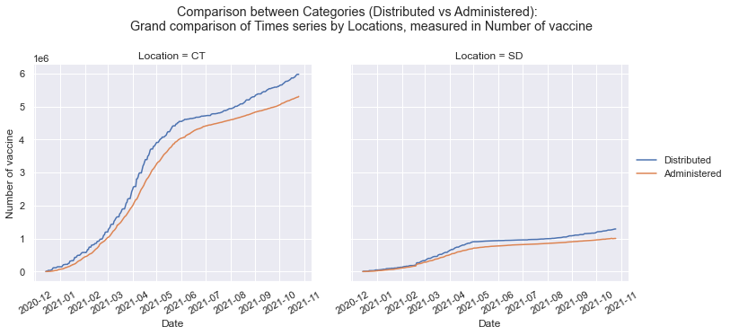

```python
# Visualization
sns.set(font_scale=1)
g = sns.FacetGrid(Grand_long, col = 'Location', size=5,
                  legend_out=True)
g.map_dataframe(sns.lineplot, x= 'Date', y= 'value', hue = 'Category')

g.fig.subplots_adjust(top=0.8) # adjust the Figure in rp
g.fig.suptitle('Comparison between Categories (Distributed vs Administered): \n Grand comparison of Times series by Locations, measured in Number of vaccine')
g.set_xticklabels(rotation = 30)
g.set_axis_labels("Date", "Number of vaccine")
g.add_legend()
```

### Grand comparison of Daily change by Locations, measured in Number of vaccine

```python
# data cleaning
Grand_long_diff = diff_bygroup(df = Grand_long,
             sorting_col_list=['Location', 'Category'])
Grand_long_diff = Grand_long_diff.dropna(axis = 0)
```

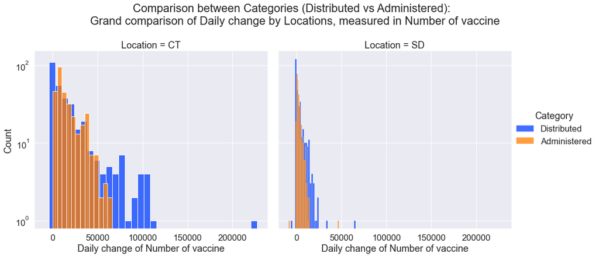

```python
# data cleaning
Grand_long_diff = diff_bygroup(df = Grand_long,
             sorting_col_list=['Location', 'Category'])
Grand_long_diff = Grand_long_diff.dropna(axis = 0)

# Visualization
sns.set(font_scale=1.5)
g = sns.FacetGrid(Grand_long_diff, col = 'Location', hue = 'Category', size=7,
                  palette=sns.color_palette('bright')[:3],
                  legend_out=True)
g.map(sns.histplot, 'diffs')

g.fig.subplots_adjust(top=0.8) # adjust the Figure in rp
g.fig.suptitle('Comparison between Categories (Distributed vs Administered): \n Grand comparison of Daily change by Locations, measured in Number of vaccine')
g.set_axis_labels("Daily change of Number of vaccine", 'Count')
g.add_legend()
g.set(yscale='log')
```

```python
# two-sample Kolmogorov-Smirnov test for goodness of fit:
# p-value for testing if distribution differ by categoris.
# tests are run for each subplot.
Grand_long_diff.drop(columns=['value']).\
    pivot(index=['Date', 'Location'], columns='Category', values='diffs').\
    reset_index().\
    drop(columns=['Date']).\
    groupby(['Location']).\
    apply(lambda df: stats.ks_2samp(df.Administered, df.Distributed)[1])
```

```
Location
CT    3.013765e-12
SD    4.483280e-18
dtype: float64
```

### Comparison of Time series by Vaccines and Locations, measured in Number of vaccine

- 'Distributed_Janssen', 'Distributed_Moderna', 'Distributed_Pfizer', 'Distributed_Unk_Manuf'
- 'Administered_Janssen', 'Administered_Moderna', 'Administered_Pfizer', 'Administered_Unk_Manuf'

```python
# data cleaning
Vaccines_long = pd.melt(vacc, id_vars=['Date', 'Location'],
                           value_vars=['Distributed_Janssen', 'Distributed_Moderna', 'Distributed_Pfizer', 'Distributed_Unk_Manuf',
                                       'Administered_Janssen', 'Administered_Moderna', 'Administered_Pfizer', 'Administered_Unk_Manuf'],
                           ignore_index=False)

Category_Vaccine = Vaccines_long.variable.str.split('_', n = 1, expand = True)
Category_Vaccine = Category_Vaccine.rename({0: 'Category', 1: 'Vaccine'}, axis=1)
Vaccines_long = pd.concat([Vaccines_long, Category_Vaccine], axis=1)
Vaccines_long = Vaccines_long.reset_index(drop=True)
```

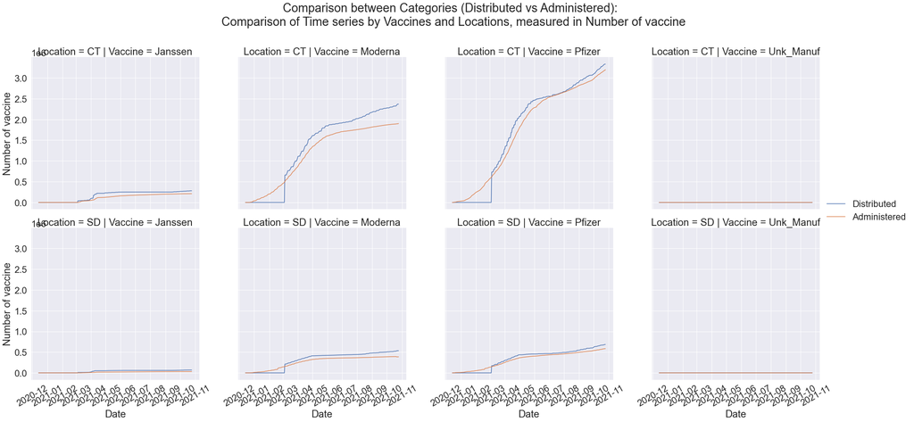

```python
# Visualization
sns.set(font_scale=2)
g = sns.FacetGrid(Vaccines_long, col='Vaccine', row = 'Location', size = 7,
                  legend_out=True)
g.map_dataframe(sns.lineplot, x= 'Date', y= 'value', hue = 'Category')

g.fig.subplots_adjust(top=0.85) # adjust the Figure in rp
g.fig.suptitle('Comparison between Categories (Distributed vs Administered): \n Comparison of Time series by Vaccines and Locations, measured in Number of vaccine')
g.set_xticklabels(rotation = 30)
g.set_axis_labels("Date", "Number of vaccine")
g.add_legend()
```